# Bellabit_Report

2023-01-19

# Case Brief

## Bellabit- case Study

Urška Sršen and Sando Mur founded Bellabeat, a high-tech company that manufactures health-focused smart products.

### Ask

Sršen asks to analyze smart device usage data in order to gain insight into how consumers use non-Bellabeat smart devices. She then wants you to select one Bellabeat product to apply these insights to in your presentation.

Case Study Roadmap -

1. What are some trends in smart device usage?
2. How could these trends apply to Bellabeat customers?
3. How could these trends help influence Bellabeat marketing strategy?

### Prepare

Importing 2 three datasets:

1. dailyActivity_merged
2. sleepDay_merged

### Process

Install packages and Load Libraries

```r
library(tidyverse)
library(janitor)
```

```r
library(dplyr)
library(ggplot2)
library(readr)
library(forcats)
library(lubridate)
```

Import datasets

```r
daily_activity <- read_csv("C:/Users/tamon/Desktop/Google Analytics Course/Case Study/Dataset/dailyActivity_merged.csv")
sleep_day <- read_csv("C:/Users/tamon/Desktop/Google Analytics Course/Case Study/Dataset/sleepDay_merged.csv")
## Cleaning & Formatting
daily_activity %>%
  duplicated() %>%
  sum()
```

```
## [1] 0
```

```r
sleep_day %>%
  duplicated() %>%
  sum()
```

```
## [1] 3
```

```r
## Remove duplicate rows
sleep_day <- sleep_day %>%
  distinct() %>%
  drop_na()

sleep_day %>%
  duplicated() %>%
  sum()
```

```
## [1] 0
```

```r
## Checking distinct IDs
n_distinct(daily_activity$Id)
```

```
## [1] 33
```

```r
n_distinct(sleep_day$Id)
```

```
## [1] 24
```

```r
## Make all columns lower case
daily_activity <- rename_with(daily_activity, tolower)
sleep_day <- rename_with(sleep_day,tolower)

## make all columns as date for ease of merge
daily_activity <- daily_activity %>%
  rename(date = activitydate)
head(daily_activity)
```

```
## # A tibble: 6 × 15
##         id date  total…¹ total…² track…³ logge…⁴ verya…⁵ moder…⁶ light…⁷ seden…⁸
##      <dbl> <chr>   <dbl>   <dbl>   <dbl>   <dbl>   <dbl>   <dbl>   <dbl>   <dbl>
## 1   1.50e9 4/12…   13162    8.5     8.5        0    1.88   0.550    6.06       0
## 2   1.50e9 4/13…   10735    6.97    6.97       0    1.57   0.690    4.71       0
## 3   1.50e9 4/14…   10460    6.74    6.74       0    2.44   0.400    3.91       0
## 4   1.50e9 4/15…    9762    6.28    6.28       0    2.14   1.26     2.83       0
## 5   1.50e9 4/16…   12669    8.16    8.16       0    2.71   0.410    5.04       0
## 6   1.50e9 4/17…    9705    6.48    6.48       0    3.19   0.780    2.51       0
## # … with 5 more variables: veryactiveminutes <dbl>, fairlyactiveminutes <dbl>,
## #   lightlyactiveminutes <dbl>, sedentaryminutes <dbl>, calories <dbl>, and
## #   abbreviated variable names ¹totalsteps, ²totaldistance, ³trackerdistance,
## #   ⁴loggedactivitiesdistance, ⁵veryactivedistance, ⁶moderatelyactivedistance,
## #   ⁷lightactivedistance, ⁸sedentaryactivedistance
```

```r
sleep_day <- sleep_day %>%
  rename(date = sleepday)
head(sleep_day)
```

```
## # A tibble: 6 × 5
##           id date                  totalsleeprecords totalminutesasleep totalt…¹
##        <dbl> <chr>                             <dbl>              <dbl>    <dbl>
## 1 1503960366 4/12/2016 12:00:00 AM                 1                327      346
## 2 1503960366 4/13/2016 12:00:00 AM                 2                384      407
## 3 1503960366 4/15/2016 12:00:00 AM                 1                412      442
## 4 1503960366 4/16/2016 12:00:00 AM                 2                340      367
## 5 1503960366 4/17/2016 12:00:00 AM                 1                700      712
## 6 1503960366 4/19/2016 12:00:00 AM                 1                304      320
## # … with abbreviated variable name ¹totaltimeinbed
```

```r
daily_activity <- daily_activity %>%
  mutate(date = as.Date(date, format = "%m/%d/%Y"))

sleep_day <- sleep_day %>%
  mutate(date = as.Date(date,format ="%m/%d/%Y %I:%M:%S %p" , tz=Sys.timezone()))
```

### Analyze/Share

1. The below bar chart shows there is not a strong majority of light or sedentary users as per the step activity level.

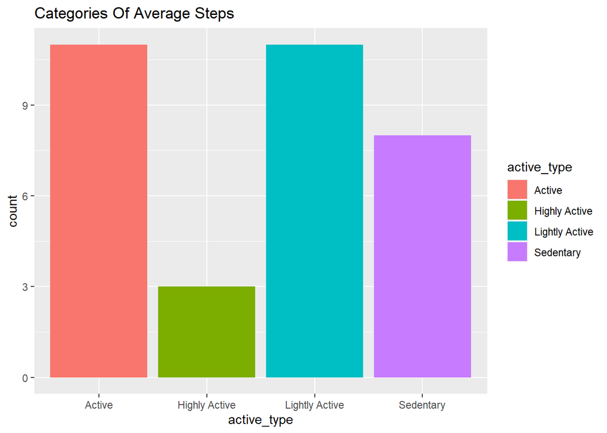

```r
stepcategories <- daily_activity %>%
  group_by(id) %>%
  summarise(avg_step= mean(totalsteps)) %>%
  mutate (active_type=case_when (
    avg_step <5000 ~ "Sedentary",
    avg_step >=5000 & avg_step< 8000 ~"Lightly Active",
    avg_step>=8000 & avg_step <12000~"Active",
    avg_step >=12000 ~ 'Highly Active'))

ggplot(data = stepcategories)+
  geom_bar(mapping = aes(x=active_type,fill=active_type))+
  labs(title = "Categories Of Average Steps")
```

2. The visuals show that more users are using their devices to track steps than sleep. More than 25 users have high usage of the device for tracking steps while only 9 of users have high usage of the device for tracking sleep.

```r
##step_daily_active
step_daily_activity <- daily_activity %>%
  group_by(id) %>%
  summarize(days_step = n_distinct(date))
head(step_daily_activity)
```

```
## # A tibble: 6 × 2
##           id days_step
##        <dbl>     <int>
## 1 1503960366        31
## 2 1624580081        31
## 3 1644430081        30
## 4 1844505072        31
## 5 1927972279        31
## 6 2022484408        31
```

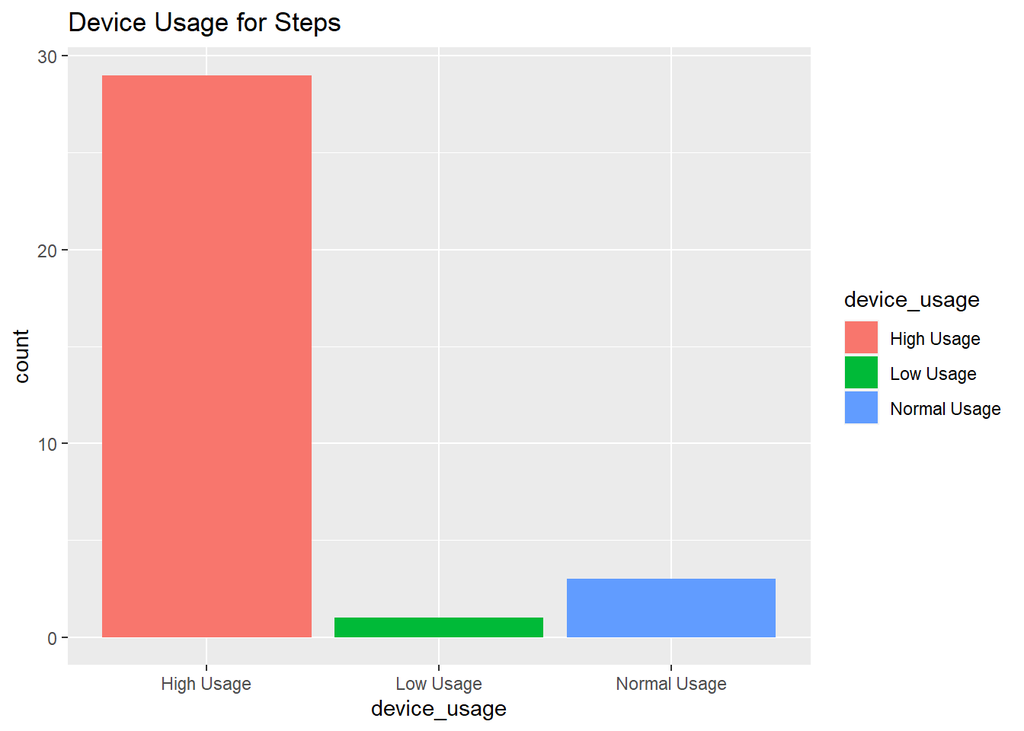

```r
daily_step_by_category <- step_daily_activity %>%
  mutate(device_usage = case_when(
    days_step <=15 ~ 'Low Usage',
    days_step >15 & days_step <= 25 ~ 'Normal Usage',
    days_step >25 ~ 'High Usage',
    TRUE~'Otherwise'))

p <- ggplot(data = daily_step_by_category)+
  geom_bar(mapping = aes(x = device_usage, fill=device_usage))+
  labs(title = "Device Usage for Steps")
p
```

```r
##Usage_sleep_day
usage_sleep_day <- sleep_day %>%
  group_by(id) %>%
  summarize(days_sleep = n_distinct(date))
head(usage_sleep_day)
```

```
## # A tibble: 6 × 2
##           id days_sleep
##        <dbl>      <int>
## 1 1503960366         25
## 2 1644430081          4
## 3 1844505072          3
## 4 1927972279          5
## 5 2026352035         28
## 6 2320127002          1
```

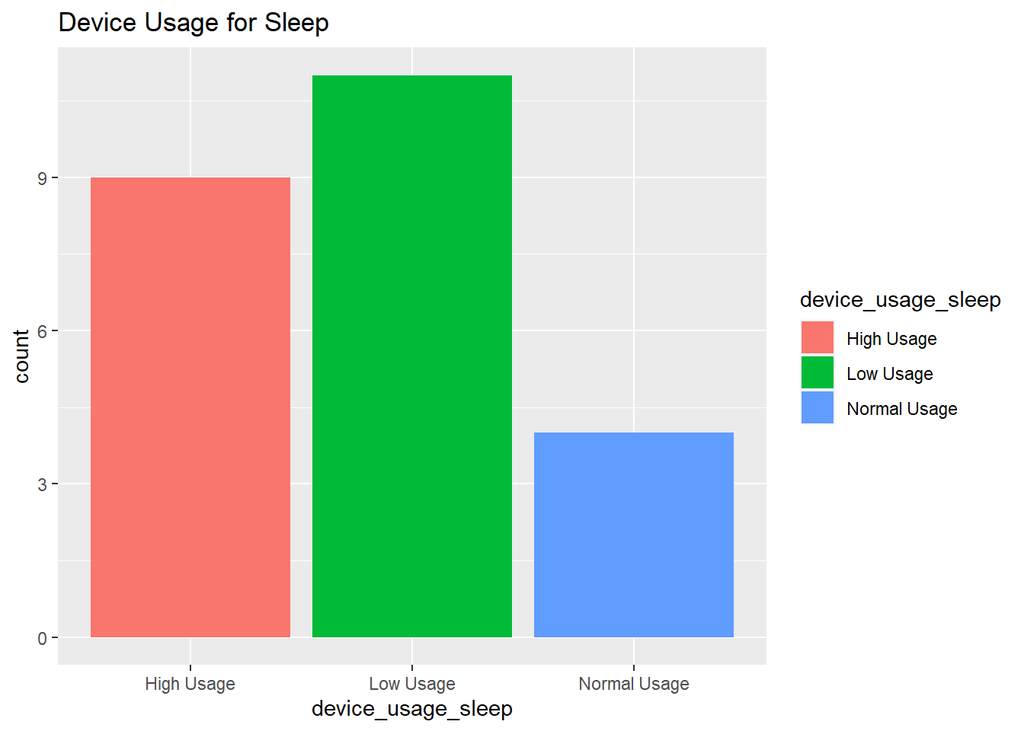

```r
daily_sleep_by_category <- usage_sleep_day %>%
  mutate(device_usage_sleep = case_when(
    days_sleep <=15 ~ 'Low Usage',
    days_sleep >15 & days_sleep <= 25 ~ 'Normal Usage',
    days_sleep >25 ~ 'High Usage',
    TRUE~'Otherwise'))

q <- ggplot(data = daily_sleep_by_category)+
  geom_bar(mapping = aes(x = device_usage_sleep, fill=device_usage_sleep))+
  labs(title = "Device Usage for Sleep")
q
```

3. There is a positive correlation between steps and calories burned, but the correlation is weaker when calories burned is correlated to total active minutes in a day.

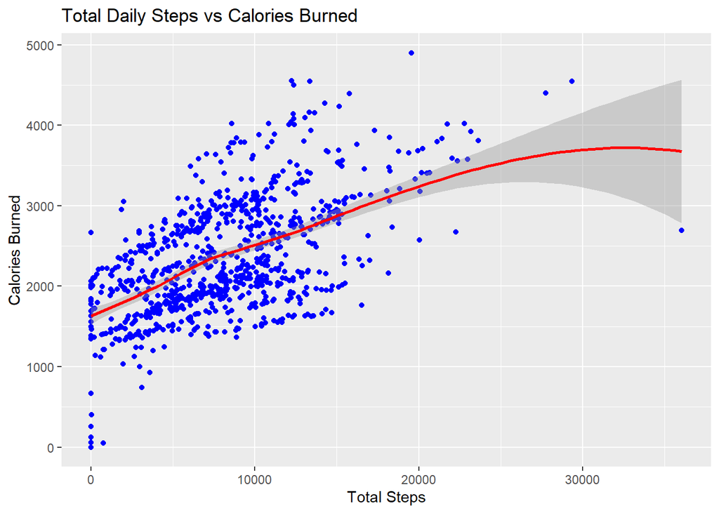

```r
##Total Steps and total calories burned

a<-ggplot(data = daily_activity)+
  geom_point(mapping = aes(x = totalsteps, y = calories),color="blue")+
  geom_smooth(mapping = aes(x = totalsteps, y = calories),color="red")+
  labs(title = "Total Daily Steps vs Calories Burned",x="Total Steps", y="Calories Burned")
a
```

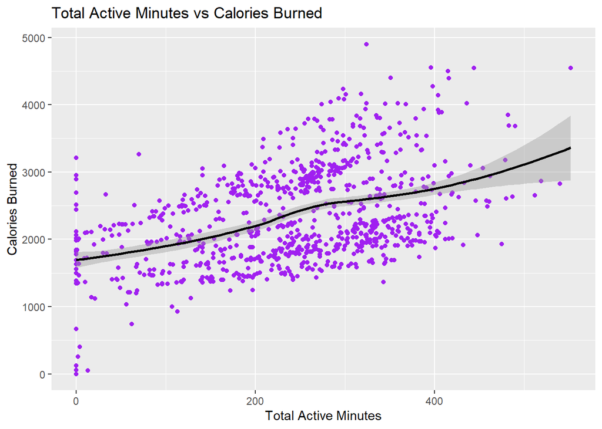

```r
##Total active minutes and total calories burned

daily_activity_new <-daily_activity %>%
  mutate(total_active_minutes= veryactiveminutes+fairlyactiveminutes+lightlyactiveminutes)

b<-ggplot(data = daily_activity_new)+
  geom_point(mapping = aes(x = total_active_minutes, y = calories),color="purple")+
  geom_smooth(mapping = aes(x = total_active_minutes, y = calories),color="black")+
  labs(title = "Total Active Minutes vs Calories Burned",x="Total Active Minutes", y="Calories Burned")

b
```

4. There are significant number of users who are getting below normal sleep due to stress/other issues

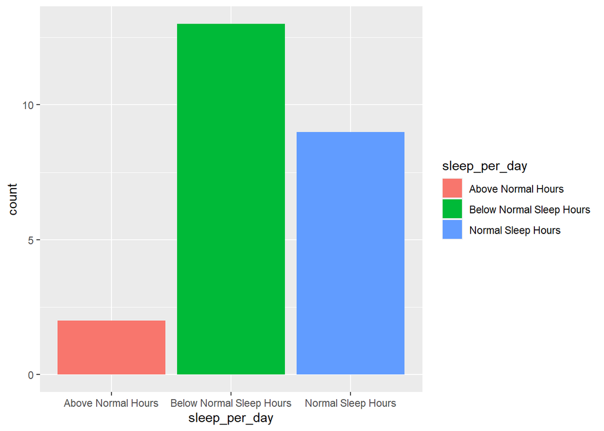

```r
## Below Normal Sleep Hours

avg_minutes_asleep <- sleep_day %>%
  group_by(id) %>%
  summarize(avg_asleep = mean(totalminutesasleep))


avg_minutes_asleep1 <- avg_minutes_asleep %>%
  mutate(sleep_per_day = case_when(
    avg_asleep <=420 ~ 'Below Normal Sleep Hours',
    avg_asleep >421 & avg_asleep <= 480 ~ 'Normal Sleep Hours',
    avg_asleep >480 ~ 'Above Normal Hours',
    TRUE~'Otherwise'))

ggplot(data = avg_minutes_asleep1)+
  geom_bar(mapping = aes(x = sleep_per_day, fill=sleep_per_day))
```